# Welcome to Stat 703

Abraham Arbelaez

2024-01-26

##### First of all, welcome to Stat 703: Introduction to Statistical Methods for the Sciences!

My name is [Abraham Arbelaez](https://abraham-arbelaez.github.io/), and I am the Teaching Assistant for the class taught by [Dr. Gary Gadbury](https://www.k-state.edu/stats/about/people/gadbury.html). I am excited to embark in this journey together! As Dr. Gadbury already said, we will be using R to perform operations and analyze data. R can look intimidating at first, but no worries! These guides are aimed to help you understand the material even more and implement some *healthy* statistics and coding into your lives.

My teaching philosophies are engagement, hands-on and student-centered learning. I was too in your shoes and sometimes trying to learn a concept was tough when I was certainly not interested in the data itself. These guides will be interactive and will have code snippets, that way you can replicate it and later run it on your own! If you have additional questions and/or suggestions please [do reach out](https://www.k-state.edu/stats/about/people/grad.html)!

**Disclaimer: These Markdowns are not intended to be a replacement of the textbook nor lectures.** It is no secret that students that read the textbook and go to class tend to perform very well. So go over these guides for when you are in need of help, and/or you want to reinforce your learning outside of class.

Welcome to Stat 703, and may the force be with you!

[figure not shown]

# Summarizing Data

Summarizing Data is very important! An overview of our data can help identifying common and/or unusual features of it. As you may already know, our data can be classified into two big types: Qualitative (or categorical), and Quantitative (or numeric). There are different techniques for summarizing data and it relies on the type of data we have.

## Categorical Data

Categorical Data is a type of qualitative data that can be grouped into categories instead of being measured numerically. Reiterating what the textbook says:

> The results can be the actual counts in each category, or they can be expressed as proportions or percentages

### Summarizing and Plotting Categorical Data

The fun part begins! The first dataset that we will use is the `students.csv` that you can find attached. The fun part about this is that the different observations in this data are all of you! There are three variables:

- section: Class section (categorical variable)
- degreeProgram: Degree program (categorical variable)
- classLevel: Class level (categorical variable)

Let’s summarize this categorical data to answer some cool questions as which section has the highest enrollment, or how many different majors are enrolled in this class.

First off, you may want to inspect the data. Just by scrolling through the file you can get familiarized with it.

Stat 703 students Spring 2024

| section | degreeProgram | classLevel |
| --- | --- | --- |
| STAT 703 A | Entomology | Graduate PhD |
| STAT 703 A | Microbiology | Graduate PhD |
| STAT 703 A | Veterinary Biomedical Science | Graduate Masters |
| STAT 703 A | Biology | Graduate Masters |
| STAT 703 A | Hort & Natural Resources | Graduate Masters |
| STAT 703 A | Genetics | Graduate Masters |
| STAT 703 A | Pathobiology | Graduate PhD |
| STAT 703 A | Agronomy | Graduate Masters |
| STAT 703 A | Agronomy | Graduate Masters |
| STAT 703 A | Elec and Computer Engg | Graduate PhD |
| STAT 703 A | Biological And Agric Engg | Graduate Masters |
| STAT 703 A | Animal Science | Graduate Masters |
| STAT 703 A | Agronomy | Graduate Masters |
| STAT 703 A | Animal Science | Graduate PhD |
| STAT 703 A | Animal Science | Graduate Masters |
| STAT 703 A | Biochemistry | Junior |
| STAT 703 A | Chemical Engineering | Graduate PhD |
| STAT 703 A | Genetics | Graduate Masters |
| STAT 703 A | Veterinary Biomedical Science | Graduate Masters |
| STAT 703 A | Computer Science | Graduate Masters |
| STAT 703 A | Elec and Computer Engg | Graduate PhD |
| STAT 703 A | Grain Science | Non Degree Graduate |
| STAT 703 A | Industrial Engineering | Graduate PhD |
| STAT 703 A | Health and Human Sciences | Graduate PhD |
| STAT 703 A | Agronomy | Graduate Masters |
| STAT 703 A | Civil Engineering | Senior |
| STAT 703 A | Animal Science | Graduate Masters |
| STAT 703 A | Animal Science | Graduate Masters |
| STAT 703 A | Entomology | Graduate Masters |
| STAT 703 A | Animal Science | Graduate Masters |

[output cut: 56 more lines]

Let’s say we want to know the number of students in each section.

First we use the `table()` function to create our frequency table. We will store the result in a new variable called section. The `students$section` means that we will be working with the column “section” in the students dataset.

```
# Making table
section <- table(students$section)
```

Once we created the variable section, we can see it just by typing it and running R!

```
# Printing the frequency table
section
```

We have an output! Our output looks like this:

Frequency table of different sections for STAT 703 Spring 2024

| STAT 703 A | STAT 703 ZA |
| --- | --- |
| 33 | 53 |

The proverb “A picture is worth a thousand words” refers to the idea that one still image can sometimes communicate many different and often complex ideas. In this context, plots will be our best friends when summarizing/communicating our data analyses.

[figure not shown]

By typing the `barplot()` function you can generate a bar plot of the table we just created. Remember that the table created is stored under the variable name `section`.

```
# Constructing the barplot
barplot(section)
```

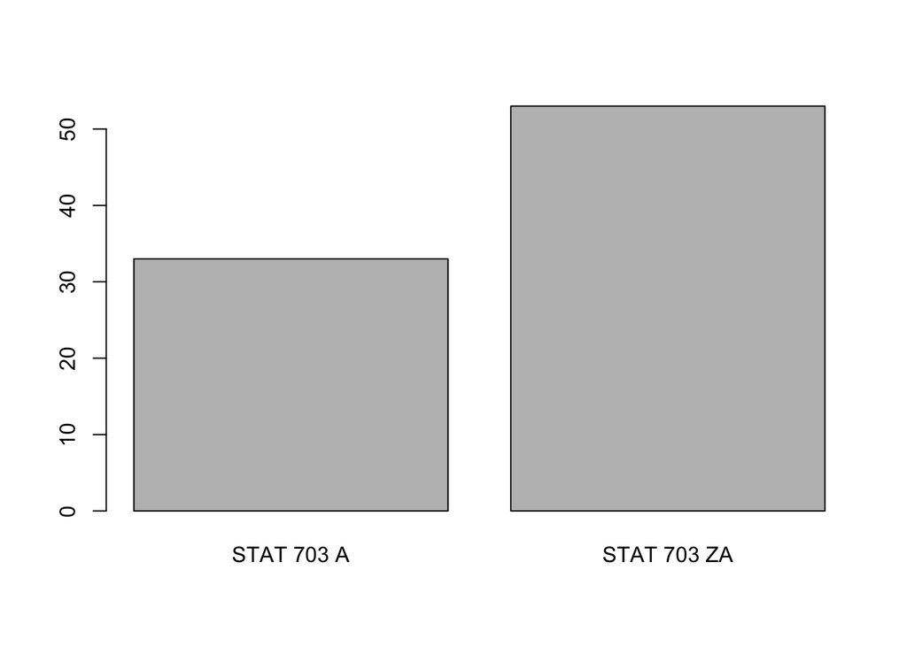

An alternative to barplots are pie charts. Just by typing the `pie()` function and running it you can create it yourself!

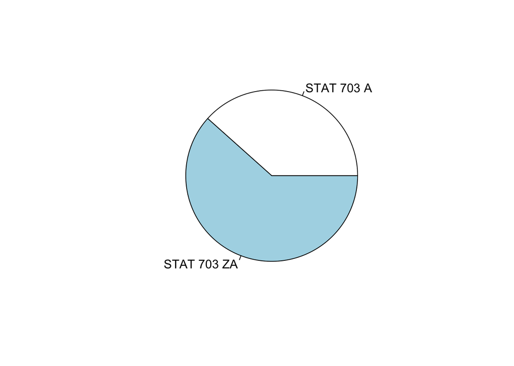

```r
pie(section)
```

##### Try it yourself!

###### Case study I

You want to know the number of students that are Graduate Masters in our `students` dataset. The variable that we are using for this is `classLevel`.

Hint: replace `section` with `classLevel`

###### Answer I

There are 53 students that are Graduate Masters.

###### Code I

```
# Making table
class = table(students$classLevel)

# Showing the class level table
class

# Constructing the barplot
barplot(class)

# Constructing the pie chart
pie(class)
```

###### Output I

```
##
##         Graduate Masters             Graduate PhD                   Junior
##                       53                       17                        2
##      Non Degree Graduate Non Degree Undergraduate                   Senior
##                        7                        1                        5
##                Sophomore
##                        1
```

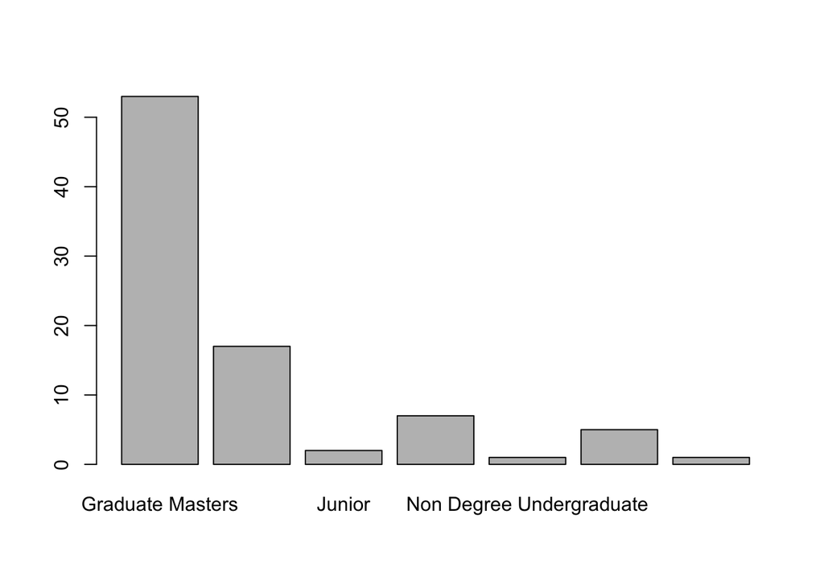

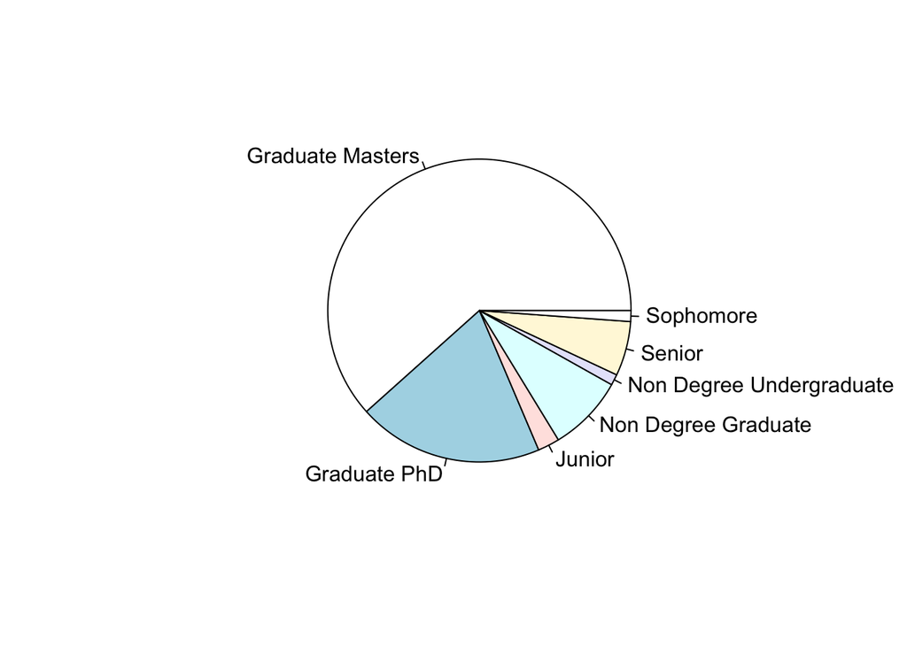

###### Case study II

Hint: Given that there are multiple categories, a barplot and a pie chart would both look funky. You can just check it using the `table()` function

###### Answer II

Nutr, Ditetcs & Sensory Sci have the most students enrolled with 9 students. There are also 8 students enrolled from Animal Science and 8 students enrolled from Biochemistry. We got a pretty diverse background!

###### Code II

```
# Making table
degree = table(students$degreeProgram)

# Showing the degree program table
degree
```

###### Output II

```
##
##                      Agronomy                Animal Science
##                             5                             8
##            Applied Statistics     Architectural Engineering
##                             1                             2
##         AS Graduate NonDegree                  Biochemistry
##                             1                             8
##        Biological & Agri Engg     Biological And Agric Engg
##                             2                             2
##                       Biology       Business Administration
##                             2                             1
##          Chemical Engineering             Civil Engineering
##                             1                             1
##              Computer Science                     Economics
##                             2                             1
##        Elec and Computer Engg                    Entomology
##                             2                             2
##   Fish, Wlife, Cons & Env Bio                  Food Science
##                             1                             4
##                      Genetics  Graduate - General Admission
##                             2                             1
##                 Grain Science     Health and Human Sciences
##                             1                             2
##      Hort & Natural Resources       Human Ecology-NonDegree
##                             4                             1
##        Industrial Engineering                   Kinesiology
##                             1                             1
##                  Microbiology           Nuclear Engineering
##                             2                             1
##   Nutr, Ditetcs & Sensory Sci                  Pathobiology
##                             9                             2
##   Personal Financial Planning                    Physiology
##                             1                             1
##  Prof Sci Applied Biosciences                    Psychology
##                             1                             1
##  Reg Affairs in Animal Health Veterinary Biomedical Science
##                             3                             6
```

## Numerical Data

Numerical Data is data that can be measured with numbers. Reiterating what the textbook says:

> Numeric summaries can not only identify specific locations in the data (such as the average) but they can also quantify how disperse the values are.

### Summarizing Numerical Data

In honor of our peeps from Nutrition, our second dataset will be the `diets.csv` that you can also find attached. This data is downloaded from [kaggle](https://www.kaggle.com/datasets/thedevastator/healthy-diet-recipes-a-comprehensive-dataset?select=keto.csv), a website where you can find multiple datasets.

The `diets.csv` dataset consists of recipes from different diets and cuisine. It includes information on the macronutrients of each recipe. These are the 6 different variables:

- Diet_type: The type of diet the recipe is for (categorical variable)
- Recipe_name: The name of the recipe (categorical variable)
- Cuisine_type: The cuisine the recipe is from (categorical variable)
- Protein.g.: The amount of protein in grams (numerical variable)
- Carbs.g.: The amount of carbs in grams (numerical variable)
- Fat.g.: The amount of fat in grams (numerical variable)

#### Measures of location

The measures of location help us describe the central tendency of the data. These include the mean, median and mode. We can find the mean protein of the recipes in our dataset by using the `mean()` function. Don’t forget that since we are interested in the protein, we must type the `dataset$NameOfColumn`, so `diets$Protein.g.`

```r
# Calculating the mean for protein
mean(diets$Protein.g.)
```

```
## [1] 83.2315
```

We can also calculate the median by using the `median()` function

```r
# Calculating the median for protein
median(diets$Protein.g.)
```

```
## [1] 56.28
```

Note how **the mean for protein is greater than the median**! What does it mean? **It means that our protein is positively skewed, so that most of our values are clustered around the left tail of our distribution.**

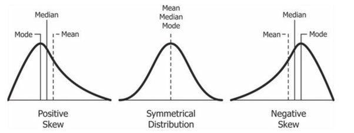

We can also check the quartiles by using the `quantile()` function. As a reminder, quartiles are values that divide a dataset into four equal parts. In this case, we are dividing the variable `Protein.g.` into the four equal parts.

```r
# Calculating the quartiles for protein
quantile(diets$Protein.g.)
```

```
##        0%       25%       50%       75%      100%
##    0.0000   24.4150   56.2800  112.3575 1273.6100
```

This means that we will find recipes from 0 grams of protein to 1273.61 grams of protein! Quite a wide range! Note how the 50% value is the same number as our median. This is because our second quartile (Q2) is the median of the dataset, representing the middle value when the data is ordered.

We can calculate the five-number summary and the mean by using the `summary()` function. Our output is similar to quantile. However, we have the mean included.

```r
# Calculating five-number summary and mean for protein
summary(diets$Protein.g.)
```

```
##    Min. 1st Qu.  Median    Mean 3rd Qu.    Max.
##    0.00   24.41   56.28   83.23  112.36 1273.61
```

You can also find a certain percentile just by changing the `quantile()` function a little bit. Recall that percentiles are similar to quartiles but divide a dataset into 100 equal parts instead of just four. The pth percentile represents the value below which p percent of the data falls. So for example if we want to calculate the 40th percentile of the variable `protein` in the `diets` dataset, the 40th percentile (P40) would be the value below which 40% of the data falls. In this case: 41.67 grams of protein.

```r
# Calculating the 40th percentile for protein
quantile(diets$Protein.g., probs = c(0.40))
```

```
##   40%
## 41.67
```

##### Try it yourself!

###### Case study III

Now try finding the five-number summary and the mean of `Carbs.g.` in the recipes from the dataset. Can you also find the 98th percentile of `Carbs.g.`?

Hint: replace `Protein.g.` with `Carbs.g.`

###### Answer III

The five-number summary and the mean of Carbs are

- Min. 0.06
- 1st Qu. 36.16
- Median 93.42
- Mean 152.12
- 3rd Qu. 205.91
- Max. 3405.55

The 98th percentile of carbs is 653.226 grams. Quite a lot of carbs!

###### Code III

```
# Calculating five-number summary and mean for carbs
summary(diets$Carbs.g.)

# Calculating the 40th percentile for carbs
quantile(diets$Carbs.g., probs = c(0.98))
```

###### Output III

```
##    Min. 1st Qu.  Median    Mean 3rd Qu.    Max.
##    0.06   36.16   93.42  152.12  205.91 3405.55
```

```
##     98%
## 653.226
```

#### Measures of dispersion

Measures of dispersion are statistical measures that describe how spread out or dispersed a set of data is. They provide insights into the variability or consistency of the data points. Some common measures of dispersion are range, IQR, variance, and standard deviation.

We can obtain the range for the variables `Protein.g.` and `Fat.g.` by using the `range()` function

```r
# Calculating the range of protein
range(diets$Protein.g.)
```

```
## [1]    0.00 1273.61
```

```r
# Calculating the range of fat
range(diets$Fat.g.)
```

```
## [1]    0.00 1930.24
```

Note that our range for protein has the same values as the 0th percentile and 100th percentile from above. It is a big range, but compared to fat, fat has a wider range!

A better way to measure variation is the interquartile range (IQR), which is the difference between the third quartile (Q3) and the first quartile (Q1). You can use the `IQR()` function or just subtract Q3 and Q1 by hand.

```r
# using IQR function for protein and fat
IQR(diets$Protein.g.)
```

```
## [1] 87.9425
```

```r
IQR(diets$Fat.g.)
```

```
## [1] 117.2225
```

```r
# calculating IQR by hand for protein and fat
112.3575 - 24.4150
```

```
## [1] 87.9425
```

```r
158.29 - 41.07
```

```
## [1] 117.22
```

You can see that by using the IQR, it seems that `Fat.g.` has a wider spread compared to `Protein.g.`

A more common way for measuring the variation is the variance (and standard deviation). Variance measures how far each data point in the set is from the mean and provides an average of the squared differences. The standard devation is just the squared root of the variance. You can use the functions `var()` and `sd()` correspondingly.

```r
# variance for protein and fat
var(diets$Protein.g.)
```

```
## [1] 8063.552
```

```r
var(diets$Fat.g.)
```

```
## [1] 14907.95
```

```r
# standard deviation for protein and fat
sd(diets$Protein.g.)
```

```
## [1] 89.79728
```

```r
sd(diets$Fat.g.)
```

```
## [1] 122.0981
```

This also shows that `Fat.g.` has a wider spread than `Protein.g.`

##### Try it yourself!

###### Case study IV

Can you tell if `Carbs.g.` has a wider spread compared to `Protein.g.`? Give the range, IQR, var, and sd for both.

Hint: replace `Fat.g.` with `Carbs.g.`

###### Answer IV

`Carbs.g.` has a wider spread compared to `Protein.g.`

- Range for protein: 0.00 - 1273.61
- Range for carbs: 0.06 - 3405.55
- IQR for protein: 87.9425
- IQR for carbs: 169.7525
- Variance for protein: 8063.552
- Variance for carbs: 34561.53
- Standard deviation for protein: 89.79728
- Standard deviation for carbs: 185.9073

###### Code IV

```
# Calculating the range of protein and carbs
range(diets$Protein.g.)
range(diets$Carbs.g.)

# using IQR function for protein and carbs
IQR(diets$Protein.g.)
IQR(diets$Carbs.g.)

# variance for protein and carbs
var(diets$Protein.g.)
var(diets$Carbs.g.)

# standard deviation for protein and carbs
sd(diets$Protein.g.)
sd(diets$Carbs.g.)
```

###### Output IV

```
## [1]    0.00 1273.61
```

```
## [1]    0.06 3405.55
```

```
## [1] 87.9425
```

```
## [1] 169.7525
```

```
## [1] 8063.552
```

```
## [1] 34561.53
```

```
## [1] 89.79728
```

```
## [1] 185.9073
```

### Outliers

[figure not shown]

How can we identify outliers? We can identify them through various methods, such as visual inspection of graphs, statistical tests, or using specific criteria like being more than a certain number of standard deviations away from the mean.

Following the textbook, a high outlier has a value greater than the mean plus TWO standard deviations. Similarly, a low outlier has a value less than the mean minus TWO standard devations. Large datasets (like this), a high extreme outlier is greater than the mean plus THREE standard deviations. Similarly, a low extreme outlier is smaller than the mean minus THREE standard deviations.

Let’s find some outliers in protein amount from the recipes, shall we?

```r
# Calculating outliers
mean(diets$Protein.g.) + 2*sd(diets$Protein.g.)
```

```
## [1] 262.8261
```

```r
mean(diets$Protein.g.) - 2*sd(diets$Protein.g.)
```

```
## [1] -96.36307
```

```r
# Calculating extreme outliers
mean(diets$Protein.g.) + 3*sd(diets$Protein.g.)
```

```
## [1] 352.6233
```

```r
mean(diets$Protein.g.) - 3*sd(diets$Protein.g.)
```

```
## [1] -186.1603
```

Recipes that have a protein amount of 262.82 grams or higher are considered high outliers. We have high outliers! Note that we don’t have negative outliers since it is impossible to have negative values of protein in a meal. We also have high extreme outliers since we have recipes whom have 352.62 grams or more of protein. Our largest value for protein amount is 1273 grams, that is a high extreme outlier.

### Graphs for numerical variables

#### Boxplots

The boxplot is also a graphical method used to represent the distribution of a set of data. You can create boxplots by using the `boxplot()` function.

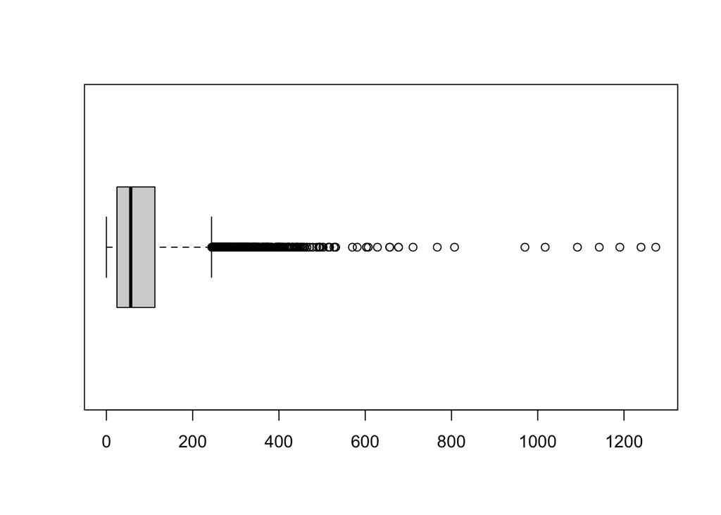

```r
# creating boxplot
boxplot(diets$Protein.g., horizontal = TRUE)
```

In this case, given that our variable is very skewed, we have a lot of dots. These dots are outliers and these values fell significantly outside the IQR range of the data.

#### Histograms

We can display the shape of a distribution with histograms. We can get it by using the `hist()` function.

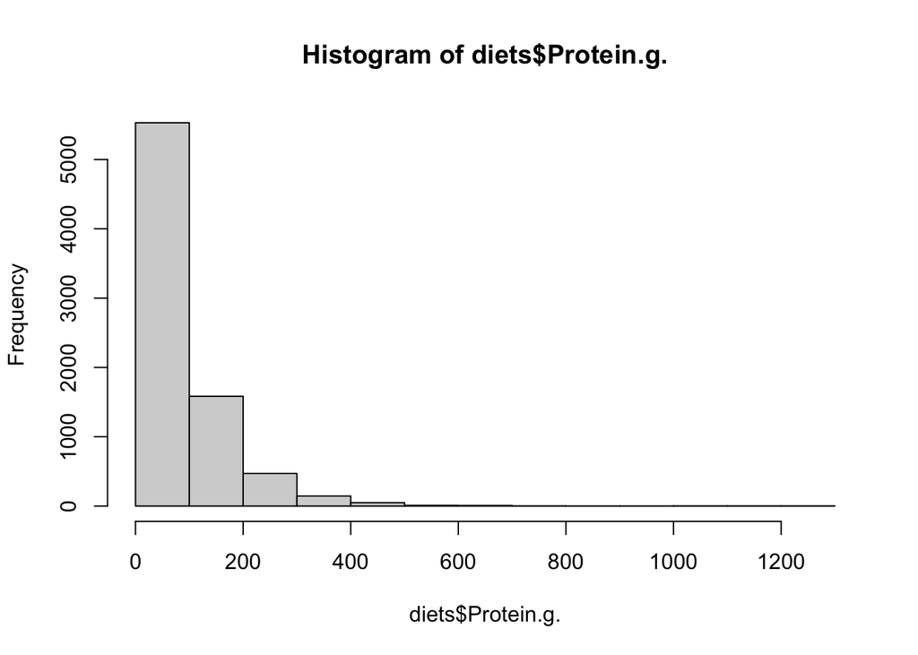

```r
# creating histogram
hist(diets$Protein.g.)
```

#### Scatterplots

This plot displays individual data points on a two-dimensional plane. Each point on the plot represents the values of two variables, making it a useful tool for visualizing correlation between them. You can use the `plot()` function. You must specify the `x-axis` and the `y-axis`. In this case, we will use Protein vs. Fat.

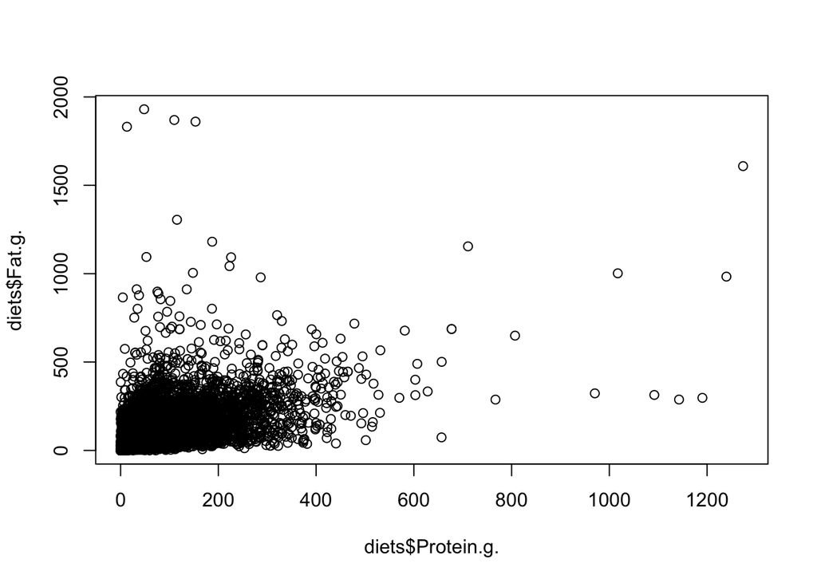

```r
# creating scatterplot
plot(diets$Protein.g., diets$Fat.g.)
```

Due to the number of outliers and number of observations, it is a little bit difficult to find whether there is a correlation. However, it seems that there might be a slight positive correlation between these two.

# Test yourself!

## Question

1. Construct a barplot by `Diet_type`. Which diet type has the least recipes?
2. Construct a pie chart by `Cuisine_type`. What type of cuisine has the most recipes in the dataset?
3. Find the mean, median, five-number summary of `Fat.g.`
4. Construct a histogram showing the distribution of `Fat.g.` and explain whether or not is skewed.

## Answer

1. The paleo diet has the least amount of recipes.
2. The american cuisine has the most recipes in the dataset.
- Min. 0.00
- 1st Qu. 41.07
- Median 84.86
- Mean 117.33
- 3rd Qu. 158.29
- Max. 1930.24
4. The variable fat is positively skewed because it has multiple high extreme outliers.

## Code

```
# Constructing a barplot by Diet_type
## making table for diet_type
type <- table(diets$Diet_type)
barplot(type)

# Constructing a pie chart by Cuisine_type
## making table for Cuisine_type
cuisine_type <- table(diets$Cuisine_type)
pie(cuisine_type)

# finding mean, median, five-number summary of fat
summary(diets$Fat.g.)

# contructing a histogram of fat
hist(diets$Fat.g.)
```

## Output

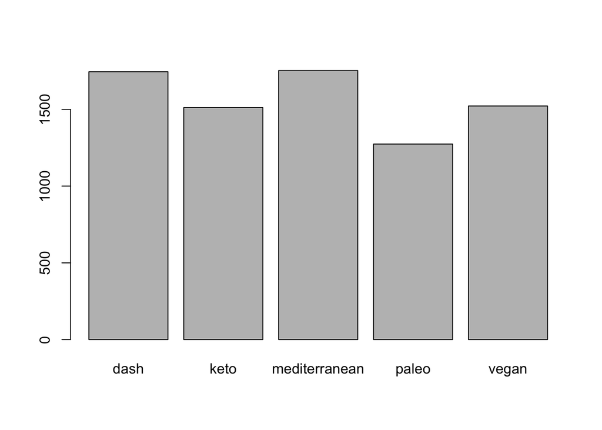

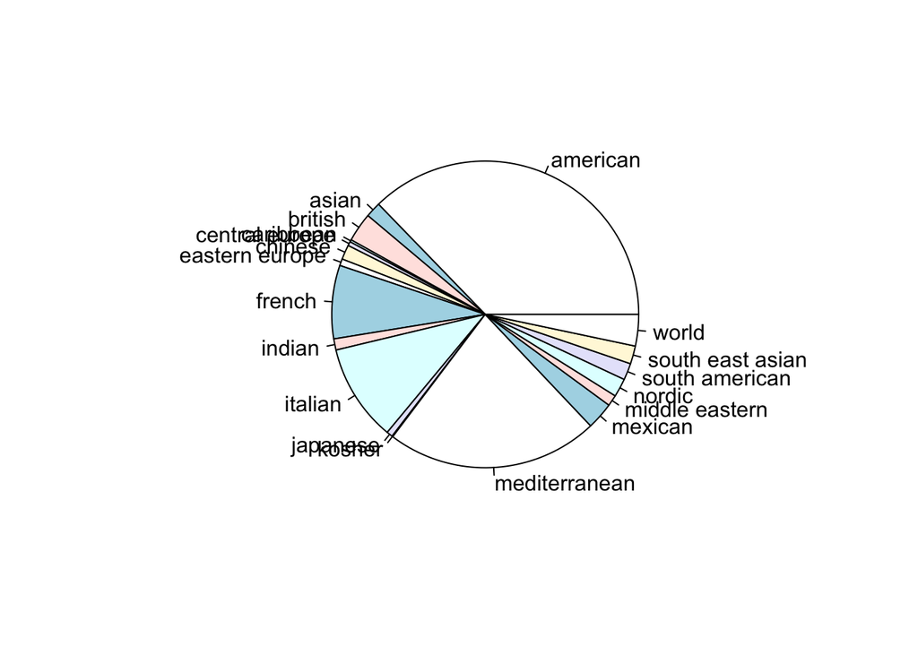

```
##    Min. 1st Qu.  Median    Mean 3rd Qu.    Max.
##    0.00   41.07   84.86  117.33  158.29 1930.24
```

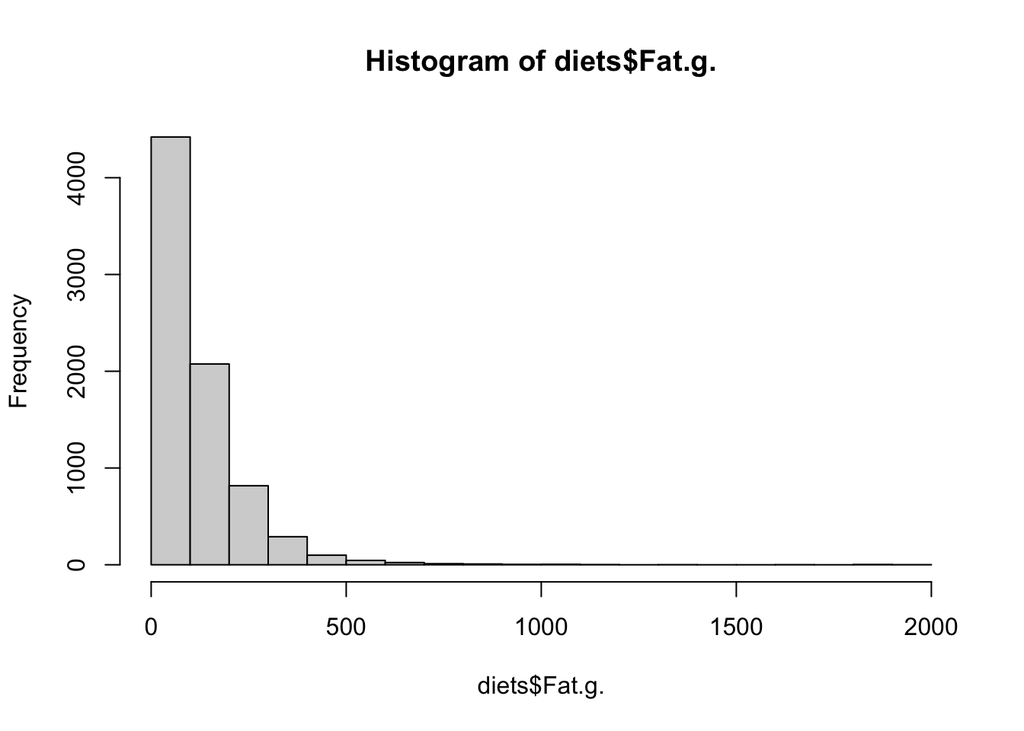